# Psychometric properties validation of HEXACO model in Taiwan sample

# 5 Estimation of Factor Loadings

- 以六因子為例，使用OLS、ML與PA方法估計出的因素負荷量之一致性係數很高，故以下僅採用OLS方法。
- 關於一致性係數的說明，請見Measurement Invariance for Gender。

```r
olsfa_6 = fa(item_poly$rho, n.obs = subject, nfactors = 6,
            rotate="oblimin", residuals=T, SMC=T, max.iter = 50,
            fm="minres", cor="poly")
mlfa_6 = fa(item_poly$rho, n.obs = subject, nfactors = 6,
            rotate="oblimin", residuals=T, SMC=T, max.iter = 50,
            fm="ml", cor="poly")
pffa_6 = fa(item_poly$rho, n.obs = subject, nfactors = 6,
            rotate="oblimin", residuals=T, SMC=T, max.iter = 50,
            fm="pa", cor="poly")

#olsfa_6$loadings - mlfa_6$loadings
#olsfa_6$loadings - pffa_6$loadings
#mlfa_6$loadings - pffa_6$loadings

factor.congruence(olsfa_6$loadings, mlfa_6$loadings, digits=4)
```

```
##         ML3     ML5     ML1     ML4     ML2     ML6
## MR1  0.9765  0.1786  0.0433  0.0010 -0.0377  0.0515
## MR3 -0.0362  0.9903  0.0665 -0.0378 -0.0537  0.1064
## MR2  0.0430  0.0683  0.9991 -0.0207  0.0540  0.0786
## MR4 -0.0792 -0.0510 -0.0205  0.9987  0.0604  0.0107
## MR5  0.0917  0.0819 -0.0480 -0.0408 -0.9938 -0.0626
## MR6  0.2357  0.0768  0.0250 -0.0215  0.0755  0.9598
```

```r
factor.congruence(olsfa_6$loadings, pffa_6$loadings, digits=4)
```

```
##         PA1     PA3     PA2     PA4     PA5     PA6
## MR1  0.9998  0.0621  0.0430 -0.0433  0.0702  0.1362
## MR3  0.0840  0.9999  0.0678 -0.0446  0.0650  0.0740
## MR2  0.0429  0.0683  1.0000 -0.0207 -0.0449  0.0572
## MR4 -0.0370 -0.0442 -0.0206  1.0000 -0.0542 -0.0138
## MR5  0.0541  0.0612 -0.0482 -0.0548  1.0000 -0.0477
## MR6  0.1162  0.0775  0.0589 -0.0118 -0.0495  0.9999
```

```r
factor.congruence(pffa_6$loadings, mlfa_6$loadings, digits=4)
```

```
##         ML3     ML5     ML1     ML4     ML2     ML6
## PA1  0.9730  0.1887  0.0439  0.0044 -0.0310  0.0441
## PA3 -0.0470  0.9889  0.0666 -0.0381 -0.0523  0.1088
## PA2  0.0433  0.0681  0.9990 -0.0206  0.0551  0.0794
## PA4 -0.0819 -0.0515 -0.0206  0.9985  0.0611  0.0112
## PA5  0.1004  0.0853 -0.0458 -0.0406 -0.9932 -0.0637
## PA6  0.2473  0.0766  0.0242 -0.0224  0.0742  0.9572
```

## 5.1 OLS & Oblimin rotation (restricted to 1-11 factors)

- Convergence not obtained when # of factors = 12.

```r
olsfa = list()
factorrange = 1:11
for (i in factorrange){
olsfa[[i]] = fa(item_poly$rho, n.obs = subject, nfactors = i,
                rotate="oblimin", residuals=T, SMC=T, max.iter = 50,
                fm="minres", cor="poly")
}
```

## 5.2 OLS & Varimax rotation (restricted to 1-11 factors)

- 因為經由斜交轉軸發現因素間相關很低（見後），所以此處也用正交轉軸。
- `psych::fa`的`rotate = "varimax"`並沒有進行Kaiser normalization。
- 所以要用`psych::Kaiser`來做Kaiser normalization。

```r
olsfa_Va = list(); olsfa_Va_n = list()
factorrange = 1:11
for (i in factorrange){
olsfa_Va[[i]] = fa(item_poly$rho, n.obs = subject, nfactors = i,
                   rotate="varimax", residuals=T, SMC=T, max.iter = 50,
                   fm="minres", cor="poly")
}
for (i in 2:11){
  olsfa_Va_n[[i]] = olsfa_Va[[i]] # One-factor model cannot rotate
  olsfa_Va_n[[i]] = kaiser(olsfa_Va[[i]], rotate = "Varimax")
}
```

- 兩種轉軸方法的因素結構具有一致性。

```r
factor.congruence(olsfa_Va[[6]]$loadings, olsfa[[6]]$loadings, digits = 4)
```

```
##         MR1     MR3     MR2     MR4     MR5     MR6
## MR6  0.9841  0.0555  0.0840 -0.0681  0.1735  0.2391
## MR3  0.1873  0.9886  0.1313 -0.1139  0.1069  0.0765
## MR2  0.1119  0.1232  0.9954 -0.0531 -0.0493  0.1011
## MR4 -0.0673 -0.0611 -0.0480  0.9979 -0.1035 -0.0275
## MR1  0.0212 -0.0715  0.0967  0.0487 -0.9944  0.1043
## MR5  0.1343  0.1199  0.1315 -0.0314 -0.0746  0.9960
```

```r
factor.congruence(olsfa_Va_n[[6]]$loadings, olsfa[[6]]$loadings, digits = 4)
```

```
##         MR1     MR3     MR2     MR4     MR5     MR6
## MR6  0.9837  0.0538  0.0843 -0.0687  0.1748  0.2406
## MR3  0.1894  0.9883  0.1310 -0.1137  0.1077  0.0757
## MR2  0.1113  0.1234  0.9954 -0.0532 -0.0496  0.1010
## MR4 -0.0664 -0.0614 -0.0480  0.9980 -0.1032 -0.0274
## MR1  0.0235 -0.0711  0.0966  0.0487 -0.9942  0.1041
## MR5  0.1317  0.1217  0.1315 -0.0312 -0.0759  0.9959
```

```r
factor.congruence(olsfa_Va[[7]]$loadings, olsfa[[7]]$loadings, digits = 4)
```

```
##         MR2     MR1     MR3     MR4     MR7     MR5     MR6
## MR2  0.9937  0.1277  0.0653 -0.0613  0.1071  0.0614  0.1053
## MR3  0.0932  0.0257  0.9797 -0.0505  0.2610 -0.0494  0.1842
## MR6  0.1266  0.9873 -0.0156 -0.1353  0.1997 -0.0352  0.1055
## MR4 -0.0515 -0.0501 -0.0746  0.9976 -0.0595  0.0964 -0.0164
## MR1  0.0861 -0.0912 -0.0237  0.0501 -0.0934  0.9962  0.1133
## MR7  0.0585  0.1707  0.1314 -0.0421  0.9941 -0.0904  0.0605
## MR5  0.1391  0.1190  0.1547 -0.0219  0.1356  0.0779  0.9923
```

```r
factor.congruence(olsfa_Va_n[[7]]$loadings, olsfa[[6]]$loadings, digits = 4)
```

```
##         MR1     MR3     MR2     MR4     MR5     MR6
## MR2  0.1537  0.1414  0.9909 -0.0575 -0.0230  0.0911
## MR3  0.8652 -0.1264  0.0516 -0.1114  0.1133  0.3704
## MR6  0.0927  0.9405  0.1185 -0.1346  0.1123  0.1585
## MR4 -0.0617 -0.0839 -0.0490  0.9936 -0.0994 -0.0149
## MR1 -0.0300 -0.0577  0.1139  0.0496 -0.9957  0.0922
## MR7  0.7213  0.4709  0.0385  0.0053  0.1262 -0.0947
## MR5  0.1605  0.1760  0.1542  0.0010 -0.0810  0.9350
```

# 6 Evaluation of Factor Solution

## 6.1 Fit Indices Table

- 較全面的適配度指標結果可見上節，本處僅呈現較常被報告的資訊。
- `sdres`：殘差矩陣的標準差
- 其他適配度指標的說明可見[此處 p.129-131](https://cran.r-project.org/web/packages/psych/psych.pdf)。
- OLS & Oblimin rotation跑出來的適配度指標數值與Varimax的相同。

```r
# A better solution is needed for the below code
fit.off = vector(); sdres = vector()
RMSR = vector(); aRMSR = vector(); RMSEA = vector()
TLI = vector(); BIC = vector(); factors = vector()

for (i in factorrange){
  factors[i] = i
  fit.off[i] = olsfa[[i]]$fit.off
  sdres[i] = sd(olsfa[[i]]$residual)
  RMSR[i] = olsfa[[i]]$rms
  aRMSR[i] = olsfa[[i]]$crms
  RMSEA[i] = olsfa[[i]]$RMSEA[1]
  TLI[i] = olsfa[[i]]$TLI
  BIC[i] = olsfa[[i]]$BIC
}

fit_df = data.frame(factors, fit.off, sdres, RMSR, aRMSR, RMSEA, TLI, BIC)
rm(fit.off, sdres, RMSR, aRMSR, RMSEA, TLI, BIC, factors)

# RMSR = root mean square of the off diagonal residuals
# aRMSR = RMSR adjusted for degrees of freedom

knitr::kable(round(fit_df,3), caption = 'Fit indices for different number of factors')
```

Fit indices for different number of factors

| factors | fit.off | sdres | RMSR | aRMSR | RMSEA | TLI | BIC |
| --- | --- | --- | --- | --- | --- | --- | --- |
| 1 | 0.380 | 0.162 | 0.117 | 0.119 | 0.098 | 0.161 | -871.314 |
| 2 | 0.529 | 0.147 | 0.102 | 0.105 | 0.093 | 0.253 | -1709.801 |
| 3 | 0.664 | 0.131 | 0.086 | 0.091 | 0.086 | 0.356 | -2589.053 |
| 4 | 0.758 | 0.120 | 0.073 | 0.078 | 0.080 | 0.445 | -3267.324 |
| 5 | 0.833 | 0.109 | 0.061 | 0.066 | 0.074 | 0.533 | -3890.038 |
| 6 | 0.878 | 0.100 | 0.052 | 0.058 | 0.069 | 0.594 | -4236.150 |
| 7 | 0.915 | 0.093 | 0.043 | 0.049 | 0.063 | 0.658 | -4571.991 |
| 8 | 0.928 | 0.089 | 0.040 | 0.046 | 0.061 | 0.679 | -4556.768 |
| 9 | 0.939 | 0.085 | 0.037 | 0.043 | 0.059 | 0.707 | -4574.888 |
| 10 | 0.947 | 0.083 | 0.034 | 0.041 | 0.057 | 0.721 | -4493.094 |
| 11 | 0.954 | 0.080 | 0.032 | 0.039 | 0.055 | 0.739 | -4425.092 |

```r
#write.csv(round(fit_df,4), "fit.csv")
```

# 7 Details of 6 factors solution (`fa.lookup`)

## 7.1 OLS & Varimax (without normalization)

```r
# Print out the 6-factor solution in details (including fit indices)
olsfa_Va[[6]] # The same amount of output using print.psych()


# Make the loading matrix easier to read
#rownames(item_info) = colnames(re_rawdf)

#olsfa_Va_n_p = list() # Pattern matrix list

#for (i in 2:11){
  #olsfa_Va_n_p[[i]] = fa.lookup(olsfa_Va_n[[i]], item_info[,-4], digits = 4) # Pattern matrix
#}

# Print out the 6-factor solution
#knitr::kable(as.data.frame(olsfa_Va_p[[6]], caption = 'Pattern matrix'))
#write.csv(olsfa_Va_n_p[[7]], "ols7_varimax (n)_P.csv")
```

[output not shown]

## 7.2 OLS & Oblimin

```r
# Print out the 6-factor solution in details (including fit indices)
olsfa[[6]] # The same amount of output using print.psych()
```

```
## Factor Analysis using method =  minres
## Call: fa(r = item_poly$rho, nfactors = i, n.obs = subject, rotate = "oblimin",
##     residuals = T, SMC = T, max.iter = 50, fm = "minres", cor = "poly")
## Standardized loadings (pattern matrix) based upon correlation matrix
##       MR1   MR3   MR2   MR4   MR5   MR6   h2   u2 com
## 1-   0.22  0.16  0.01  0.08 -0.03  0.56 0.44 0.56 1.5
## 2    0.34  0.10 -0.04 -0.04 -0.23 -0.01 0.16 0.84 2.0
## 3   -0.07  0.60  0.04 -0.17  0.02  0.06 0.42 0.58 1.2
## 4    0.13  0.20  0.45  0.00  0.00 -0.08 0.29 0.71 1.6
## 5   -0.16  0.02 -0.17  0.38 -0.06  0.02 0.22 0.78 1.9
## 6    0.37  0.27 -0.04  0.05 -0.13 -0.16 0.23 0.77 2.6
## 7   -0.04  0.17  0.06 -0.06 -0.27  0.19 0.15 0.85 2.8
## 8    0.15  0.01  0.09  0.04 -0.57  0.05 0.36 0.64 1.2
## 9-   0.05  0.26 -0.08  0.07  0.48  0.04 0.33 0.67 1.7
## 10-  0.20 -0.20  0.52  0.03  0.01  0.22 0.43 0.57 2.0
## 11  -0.16 -0.08 -0.16  0.54 -0.33  0.09 0.52 0.48 2.2
## 12-  0.49  0.17  0.02  0.10  0.02 -0.05 0.29 0.71 1.3
## 13  -0.20  0.17  0.00  0.08 -0.06  0.62 0.42 0.58 1.4
## 14-  0.56 -0.27 -0.13 -0.06 -0.13  0.09 0.40 0.60 1.8
## 15-  0.05  0.07  0.04 -0.04  0.54  0.01 0.31 0.69 1.1
## 16  -0.06  0.10  0.55  0.08 -0.03 -0.10 0.33 0.67 1.2
## 17  -0.05 -0.07  0.25  0.58 -0.07 -0.01 0.41 0.59 1.4
## 18   0.16  0.39  0.01 -0.03  0.00 -0.09 0.20 0.80 1.4
## 19-  0.30  0.03 -0.01  0.06  0.11  0.05 0.12 0.88 1.4
## 20-  0.51 -0.16 -0.07 -0.17  0.03  0.23 0.40 0.60 1.9
## 21-  0.28  0.32 -0.04  0.03  0.31  0.21 0.37 0.63 3.7
## 22   0.08  0.31  0.54 -0.02  0.20 -0.17 0.49 0.51 2.2
## 23   0.04  0.14  0.11  0.52 -0.04  0.08 0.30 0.70 1.3
## 24-  0.02  0.05 -0.34  0.02  0.21  0.06 0.16 0.84 1.9
## 25   0.01  0.27 -0.10  0.03 -0.16  0.38 0.24 0.76 2.4
## 26-  0.25 -0.08  0.11 -0.24  0.23  0.15 0.25 0.75 4.3
## 27  -0.09  0.59  0.07 -0.12 -0.05  0.11 0.40 0.60 1.2
## 28-  0.34 -0.03  0.47  0.04  0.26  0.05 0.46 0.54 2.5
## 29  -0.16  0.03 -0.07  0.48 -0.17 -0.11 0.33 0.67 1.7
## 30-  0.36 -0.06 -0.07 -0.03  0.13 -0.07 0.15 0.85 1.5
## 31-  0.30 -0.03 -0.05 -0.04  0.04  0.36 0.26 0.74 2.0
## 32-  0.58 -0.10  0.09  0.11  0.01  0.08 0.38 0.62 1.2
## 33   0.00  0.59  0.07  0.04  0.08  0.08 0.38 0.62 1.1
## 34  -0.16 -0.03  0.67 -0.02 -0.10  0.04 0.48 0.52 1.2
## 35-  0.14 -0.34 -0.24  0.20 -0.16  0.18 0.31 0.69 4.1
```

[output cut: 52 more lines]

```
## The total number of observations was  519  with Likelihood Chi Square =  4672.81  with prob <  0
##
## Tucker Lewis Index of factoring reliability =  0.594
## RMSEA index =  0.069  and the 90 % confidence intervals are  0.064 NA
## BIC =  -4236.15
## Fit based upon off diagonal values = 0.88
## Measures of factor score adequacy
##                                                 MR1  MR3  MR2  MR4  MR5
## Correlation of scores with factors             0.93 0.92 0.93 0.92 0.91
## Multiple R square of scores with factors       0.86 0.85 0.86 0.84 0.82
## Minimum correlation of possible factor scores  0.71 0.70 0.72 0.68 0.64
##                                                MR6
## Correlation of scores with factors             0.9
## Multiple R square of scores with factors       0.8
## Minimum correlation of possible factor scores  0.6
```

```r
# Make the loading matrix easier to read
# Must include the reverse item information to ensure there is no NA in dimension information
# rownames(item_info) = colnames(re_rawdf)

#olsfa_p = list() # Pattern matrix list
#olsfa_s = list() # Structure matrix list
#for (i in 1:11){
 #olsfa_p[[i]] = fa.lookup(olsfa[[i]], item_info[,-4], digits = 4) # Pattern matrix
 #olsfa_s[[i]] = fa.lookup(olsfa[[i]]$Structure, item_info[,-4], digits = 4) # Structure matrix
#}

# Print out the 6-factor solution
#knitr::kable(as.data.frame(olsfa_p[[6]], caption = 'Pattern matrix'))
#knitr::kable(as.data.frame(olsfa_p[[6]], caption = 'Structure matrix'))

#write.csv(olsfa_p[[8]], "ols8_oblique_P.csv")
#write.csv(olsfa_s[[8]], "ols8_oblique_S.csv")
#write.csv(olsfa[[7]]$Phi, "ols7_oblique_Phi.csv")
```

# 8 Visualization

## 8.1 Some resources

- [視覺化參考來源](http://rpubs.com/danmirman/plotting_factor_analysis)
- [Multiple plots arrangment 1](https://cran.r-project.org/web/packages/cowplot/vignettes/plot_grid.html)
- [Multiple plots arrangment 2](http://stackoverflow.com/questions/36198451/specify-widths-and-heights-of-plots-with-grid-arrange)
- [Axis & label](https://rstudio-pubs-static.s3.amazonaws.com/3364_d1a578f521174152b46b19d0c83cbe7e.html)

## 8.2 Multiple loading plots function

- `loadbar(loadmat, iteminfo, type, extraction)` generate plots for all possible factor solution in R & .pdf automatically
- You must specify:
  - `loading` = The object returned from either a factor analysis (`fa`) or a principal components analysis (`principal`)
  - `iteminfo` = A data.frame with the information of all items to display. The input format is: row = each item; col = item information (maindim, subdim, & statement).
  - `type` = “Pattern” (default) or “Structure” matrix. For orthogonal rotations, `type` must be “Pattern”; for oblique rotations, type can be either “Pattern” or “Structure”.
  - `extraction` = The method of initial factor loading estimation you use, e.g., `extraction = "IPF"`.

The data format for iteminfo

| maindim | subdim | statement |
| --- | --- | --- |
| Openness to Experience | Aesthetic Appreciation | 我覺得參觀美術館很無聊。 |
| Conscientiousness | Organization | 我會在事前計畫和組織要做的事，避免最後一分鐘手忙腳亂。 |
| Agreeableness | Forgiveness | 我很少有怨恨，即使面對那些對我很壞的人。 |
| Extraversion | Social Self-Esteem | 整體而言我對自己還算滿意。 |

- Optional
  - `axis` = “maindim” (default), “item”, or “statement”
  - `filename` = “faplots.pdf” (name of the pdf file)
  - `rel_widths` = c(4,1) (relative width ratio between the loading and communality plot)
  - `widthpdf` = 15 (the width of the graphics region in pdf in inches)
  - `widthheight` = 11 (the height of the graphics region in pdf in inches)
- For each solution, plot the loading (or correlation between factors and variables) as length and fill color of a bar note that the length will be the absolute value of the loading but the fill color will be the signed value.

```r
rownames(item_info) = colnames(re_rawdf)
#library(showtext)
#showtext.auto(enable = T)
#font.families()
#font.add("wqy", "wqy-microhei/wqy-microhei.ttc")
#font.add('華康中黑體', "華康中黑體.TTC")
#font.files()
#尚未處理ggplot中文支援


loadbar = function(loading, iteminfo, type="Pattern", axis="maindim", extraction = "Unknown", filename="faplots.pdf", rel_widths = c(4,1), widthpdf = 15, widthheight = 11){

  # Create the empty list first to save ggplot objects
  faplot.list = list()

  ################ Check packages by `pacman` ################

  if (!require("pacman")) install.packages("pacman"); library(pacman)
  p_load(reshape2, ggplot2, cowplot, grid, dplyr, psych)

  loadmat = list()

  if (type == "Pattern"){
    hlab = "Loading Strength"
    for(i in 1:length(loading)){
      loadmat[[i]] = fa.lookup(loading[[i]], iteminfo, digits = 4)
    }
  }
  else if (type == "Structure"){
    hlab = "Correlation (Factors, Varibles)"
    for(i in 1:length(loading)){
      item_cc = data.frame(rownames= row.names(loading[[i]]$Structure),
                           h2 = loading[[i]]$communality, com = loading[[i]]$complexity)
      loadmat[[i]] = fa.lookup(loading[[i]]$Structure, iteminfo, digits = 4)
      loadmat[[i]] = inner_join(cbind(loadmat[[i]], rownames = row.names(loadmat[[i]])), item_cc, by = "rownames")
      row.names(loadmat[[i]]) = loadmat[[i]]$rownames
      loadmat[[i]] = select(loadmat[[i]], -rownames)

    }
  }

  loadmat_l = list()

  for (i in 1:length(loadmat)){

    ################ Data transformation for further plotting ################
    loadmat[[i]] = cbind(loadmat[[i]], item = row.names(loadmat[[i]]))

    complexity = paste0("Mean item complexity = ", as.character(round(mean(loadmat[[i]]$com), 2)),
                        " (SD = ", as.character(round(sd(loadmat[[i]]$com), 2)), ")")
    submain = paste0(extraction, " method with ", loading[[i]]$rotation, " rotation. (N = ", loading[[i]]$n.obs,")")
    fit = paste0("RMSEA = ", as.character(round(loading[[i]]$RMSEA[1],3)),
                 "; BIC = ", as.character(round(loading[[i]]$BIC,3)),
                 "; TLI = ", as.character(round(loading[[i]]$TLI,3)),".")

    loadmat_l[[i]] = melt(loadmat[[i]], id = c("com","h2","maindim","subdim","statement", "item"),
                          measure = subset(colnames(loadmat[[i]]),
                                           colnames(loadmat[[i]])!="statement"&
                                           colnames(loadmat[[i]])!="com"&
                                           colnames(loadmat[[i]])!="h2"&
                                           colnames(loadmat[[i]])!="maindim"&
                                           colnames(loadmat[[i]])!="subdim"&
                                           colnames(loadmat[[i]])!="item"),
                          variable.name="Factor", value.name="Loading")

    # To make x-axis of ggplot follow the specific order (original pattern/structure matrix order)
    loadmat_l[[i]]$item = factor(loadmat_l[[i]]$item, levels = loadmat[[i]]$item)

    if (axis == "item"){
      align = 0
      vlab = "Item"
      vlabel = loadmat_l[[i]]$item
    }else if (axis == "statement"){
      align = 1
      vlab = "Item & Statement"
      vlabel = loadmat_l[[i]]$statement
    }else if (axis == "maindim"){
      align = 1
      vlab = "Item & Dimension"
      vlabel = loadmat_l[[i]]$maindim
    }

    loadmat_l[[i]]$Communality = factor(rep("Communality", nrow(loadmat_l[[i]])))

    ################ Plot Pattern/Structure Matrix ################

    assign("PS", ggplot(loadmat_l[[i]], aes(item, abs(Loading), fill = Loading)) +
      facet_wrap(~ Factor, nrow = 1) +
      geom_bar(stat = "identity") +
      coord_flip() +
      # Define the fill color gradient: blue=positive, red=negative
      scale_fill_gradient2(name = "Loading",
                           high = "blue", mid = "white", low = "red",
                           midpoint = 0, guide = F) +
      scale_x_discrete(labels = vlabel) +
      labs(x = vlab,y = hlab, title = paste("Barplot of the", type,"Matrix"), subtitle = submain, caption = "") +
      theme_bw(base_size = 10) + #use a black-and white theme with set font size
      theme(axis.text.y=element_text(hjust=align), # Align of the `axis`
            #legend.position=c(.85, .85),
            #legend.background = element_rect(fill="transparent", size=.5, linetype="dotted"),
            #text=element_text(family="華康中黑體", size=10),
            strip.background = element_rect(colour="transparent", fill="#CCCCFF"), # facet label color
            panel.background = element_rect(fill = "transparent", colour = NA),
            panel.border = element_blank(), #element_rect(colour = "#CCCCFF"),
            plot.background = element_rect(fill = "transparent", colour = NA)) +
      background_grid(major = 'x', minor = "none"))# +
      #panel_border(colour = "#CCCCFF"): The same with panel.background in theme

    ################ Plot Communality ################

    assign("COM", ggplot(distinct(loadmat_l[[i]], item, h2, Communality), aes(item, h2, fill = h2)) +
      geom_bar(stat = "identity") +
      facet_wrap(~ Communality, nrow = 1) +
      coord_flip() +
      scale_fill_gradient2(name = "h2",
                           high = "black", mid = "grey", low = "white",
                           midpoint = 0, guide = F) +
      labs(y = "Communality", title="", subtitle = complexity, caption = fit) +
      theme_bw(base_size = 10) +
      theme(axis.text.y=element_text(hjust=0), # Retain y axis labels for convenience
            axis.line.y = element_line(colour = "black"), # Make "l" type axis
            panel.border = element_blank(), # Suppress border
            strip.background = element_rect(colour="transparent", fill="gray80"), # facet label color
            axis.title.y=element_blank(), # Remove y axis lab for beauty
            axis.ticks.y=element_blank(), # Remove y axis ticks for beauty
            panel.background = element_rect(fill = "transparent", colour = NA),
            plot.background = element_rect(fill = "transparent", colour = NA)) +
      background_grid(major = 'x', minor = "none"))

    ################ Marge two plot  ################

    g.PS = ggplotGrob(PS); g.COM = ggplotGrob(COM)
    PS.heights = g.PS$heights[1:3]
    COM.heights = g.COM$heights[1:3] # same for mpg plot
    max.heights = unit.pmax(PS.heights, COM.heights) # calculate maximum heights
    g.PS$heights[1:3] = max.heights # assign max heights to PS gtable
    g.COM$heights[1:3] = max.heights # assign max heights to COM gtable

    # plot_grid() can work directly with gtables, so this works!
    faplot.list[[i]] = plot_grid(g.PS, g.COM, ncol = 2, rel_widths = rel_widths)

  }

  ################ Create pdf where each page is a separate plot ################

  pdf(filename, width = widthpdf, height = widthheight)
  for (i in 1:length(loadmat)) {
    print(faplot.list[[i]])
  }
  dev.off()

  cat("The ggplot objects are saved into a list you assign.\n\nFor example, if you assign the `loadpar` function into a variable called `faplot`, i.e., `faplot = loadpar(...)`, then the plot of m factor solution can be called by `faplot[[m]]`.\n\nFor converience, all plots are saved into a single pdf file in the working directory.")

  return(faplot.list) # Return the ggplot object for further use

}

ols_oblique_P =loadbar(olsfa, item_info[,-4], type="Pattern", axis="maindim", extraction = "OLS", filename="faplot_oblique_P.pdf")
ols_oblique_S = loadbar(olsfa, item_info[,-4], type="Structure", axis="maindim", extraction = "OLS", filename="faplot_oblique_S.pdf")
ols_varimax = loadbar(olsfa_Va, item_info[,-4], type="Pattern", axis="maindim", extraction = "OLS", filename="faplot_varimax_NEW.pdf")
# 欲印出各題敘述時 (axis="statement")，需先設定中文字體，然後在Console執行該函數，才可成功
# See pdf
```

# 9 Measurement Invariance for Gender

- 檢驗男女性在本量表的測量不變性有無不同。
- 因為看到有研究說明兩性在某些向度上有顯著差異（在本研究可能也如此 (還沒做檢定)），為釐清此差異是否具有效度，而進行測量不變性的檢驗。
- Here we follow the procedures recommended by [Nimon, K., & Reio Jr, T. G. (2011)](http://journals.sagepub.com/doi/abs/10.1177/1534484311399731) (except for CFA part).

## 9.1 Reliability

- ggplot2 & errorbar

```r
rawdf_glist = list(); itemonly_glist = list(); item.keys_glist = list(); item.scored_glist = list()
HEXACO.alphas_glist = list(); alphaCI_glist = list()
for (i in 1:2){
  rawdf_glist[[i]] = subset(rawdf, rawdf$gender == as.character(i))
  itemonly_glist[[i]] = rawdf_glist[[i]][,11:70]
  item.keys_glist[[i]] = make.keys(itemonly_glist[[i]], item.keys.list)
  item.scored_glist[[i]] = scoreItems(keys = item.keys_glist[[i]], items = itemonly_glist[[i]],
                                      totals = F, missing = F, min = 1, max = 5, digits = 3)
  output.alpha.Agree = psych::alpha(itemonly_glist[[i]][,abs(item.keys.list$Agree)], check.keys=T)
  output.alpha.Consc = psych::alpha(itemonly_glist[[i]][,abs(item.keys.list$Consc)], check.keys=T)
  output.alpha.Emo = psych::alpha(itemonly_glist[[i]][,abs(item.keys.list$Emo)], check.keys=T)
  output.alpha.Extra = psych::alpha(itemonly_glist[[i]][,abs(item.keys.list$Extra)], check.keys=T)
  output.alpha.HH = psych::alpha(itemonly_glist[[i]][,abs(item.keys.list$HH)], check.keys=T)
  output.alpha.Open = psych::alpha(itemonly_glist[[i]][,abs(item.keys.list$Open)], check.keys=T)
  HEXACO.alphas_glist[[i]] = as.numeric(c(output.alpha.Agree$total[1], output.alpha.Consc$total[1],
                                          output.alpha.Emo$total[1], output.alpha.Extra$total[1],
                                          output.alpha.HH$total[1], output.alpha.Open$total[1]))
  alphaCI_glist[[i]] = mapply(cronbach.alpha.CI, HEXACO.alphas_glist[[i]], nrow(rawdf_glist[[i]]), item.scored_glist[[i]]$n.items, .95)
}

HEXACO.alpha.gtable = data.frame(Scale = scale.names,
                                 Alpha_m = HEXACO.alphas_glist[[1]],
                                 Alpha_f = HEXACO.alphas_glist[[2]],
                                 Lower_m = alphaCI_glist[[1]][1,],
                                 Lower_f = alphaCI_glist[[2]][1,],
                                 Upper_m = alphaCI_glist[[1]][2,],
                                 Upper_f = alphaCI_glist[[2]][2,])
HEXACO.alpha.gtable = melt(setDT(HEXACO.alpha.gtable), id.vars = "Scale",
                           measure = patterns("Alpha","Lower","Upper"),
                           variable.name=c("Gender"),
                           value.name=c("Alpha", "Lower", "Upper"))
levels(HEXACO.alpha.gtable$Gender) = c("Male", "Female")
HEXACO.alpha.gtable[,3:5] = round(HEXACO.alpha.gtable[,3:5], 4)
HEXACO.alpha.gtable = arrange(HEXACO.alpha.gtable, Scale)

knitr::kable(HEXACO.alpha.gtable, caption = 'Standarized alpha and its 95% C.I. of each dimension (grouped by gender)')
```

Standarized alpha and its 95% C.I. of each dimension (grouped by gender)

| Scale | Gender | Alpha | Lower | Upper |
| --- | --- | --- | --- | --- |
| Agreeableness | Male | 0.7376 | 0.6845 | 0.7850 |
| Agreeableness | Female | 0.7664 | 0.7236 | 0.8050 |
| Conscientiousness | Male | 0.6946 | 0.6328 | 0.7498 |
| Conscientiousness | Female | 0.7287 | 0.6790 | 0.7736 |
| Emotionality | Male | 0.6876 | 0.6244 | 0.7440 |
| Emotionality | Female | 0.7229 | 0.6721 | 0.7687 |
| Extraversion | Male | 0.7368 | 0.6836 | 0.7844 |
| Extraversion | Female | 0.7851 | 0.7457 | 0.8206 |
| Honesty-Humility | Male | 0.6962 | 0.6347 | 0.7511 |
| Honesty-Humility | Female | 0.7052 | 0.6511 | 0.7540 |
| Openness to Experience | Male | 0.6479 | 0.5766 | 0.7115 |
| Openness to Experience | Female | 0.7110 | 0.6580 | 0.7588 |

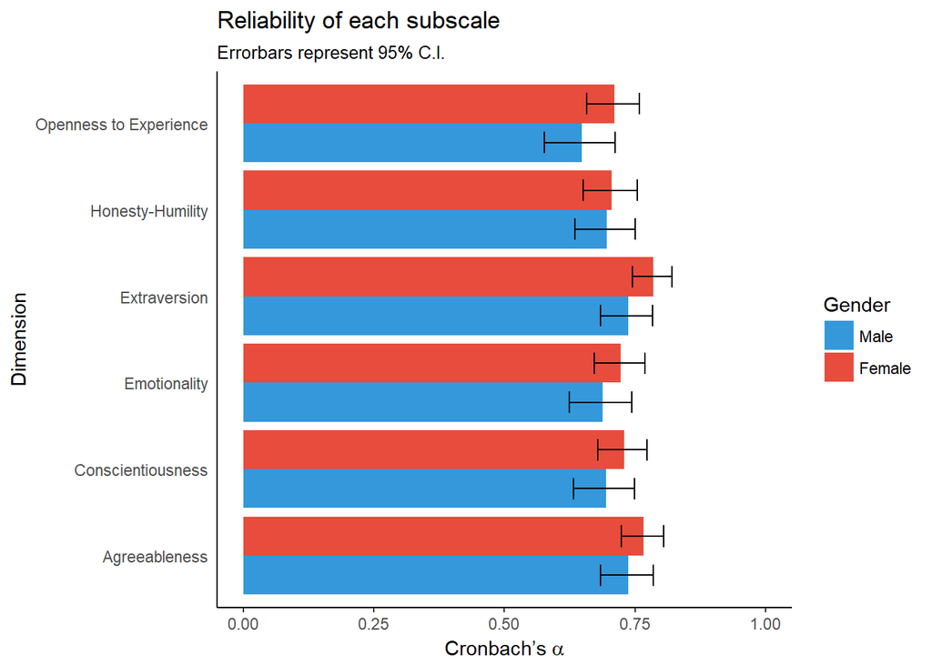

```r
ggplot(HEXACO.alpha.gtable, aes(x = Scale, y = Alpha, ymax = Upper, ymin = Lower, fill = Gender)) +
  geom_bar(stat = "identity", position = "dodge") +
  geom_errorbar(position = position_dodge(width = .9), width = .5) +
  scale_y_continuous(limits = c(0, 1)) +
  coord_flip() +
  labs(x="Dimension",y = expression(paste("Cronbach’s ", alpha)),
       title="Reliability of each subscale", subtitle = "Errorbars represent 95% C.I.") +
  theme_bw() +
  scale_fill_manual(values=c("#3498db","#e74c3c")) +
  theme(axis.line = element_line(colour = "black"), # Make "l" type axis
        panel.border = element_blank(),
        axis.ticks.y=element_blank(),
        panel.background = element_rect(fill = "transparent", colour = NA),
        plot.background = element_rect(fill = "transparent", colour = NA)
        ) +
  background_grid(major = 'none', minor = "none") # From package `cowplot`
```

```r
# write.csv(HEXACO.alpha.gtable, "alpha_gender.csv")
```

## 9.2 Factorial Structure

- I’m not sure whether the function `faBy` does the same thing we want. Besides, when I ran this procedure, it came out error.
- 男性與女性樣本在各方法所建議的因素數目相同嗎？
- 若相同，那細部因素結構會一致嗎？
1. 因素數目

```r
re_rawdf_glist = list(); item_poly_glist = list(); dummy = c("Male", "Female"); fit_ob = list()
PA_polyglist = list(); MAP_ployglist = list(); EVg = list()
for (i in 1:2){
  re_rawdf_glist[[i]] = reverse.code(item_info$re_item, rawdf_glist[[i]][11:70], mini = 1, maxi = 5)
  item_poly_glist[[i]] = polychoric(re_rawdf_glist[[i]], ML = F, std.err = F)
  subject = nrow(re_rawdf_glist[[i]])
  ##### PA #####
  PA_polyglist[[i]] = fa.parallel(item_poly_glist[[i]]$rho, n.obs = subject, fa = "both", n.iter = rep,
                                  cor = "poly", error.bars = F, SMC = T, quant = baseline/100)
  ##### MAP #####
  MAP_ployglist[[i]] = map(item_poly_glist[[i]]$rho, display='yes')
  ##### EV > 1 rule #####
  EVg[[i]] = sum(eigen(item_poly_glist[[i]]$rho, only.values = T)$values > 1)
  ##### Fit Indices #####
  fit_ob[[i]] = nfactors(item_poly_glist[[i]]$rho, n = 11, rotate = "oblimin", diagonal=F, fm = "minres",                 n.obs=subject, cor = "poly")
}
```

```
## 1555 cells were adjusted for 0 values using the correction for continuity. Examine your data carefully.
```

```
## 1572 cells were adjusted for 0 values using the correction for continuity. Examine your data carefully.
```

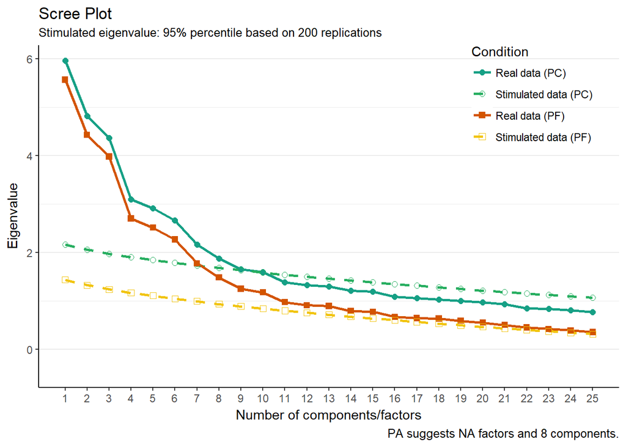

```
##
## For Male:
## Parallel analysis (PC) suggests 8 factor(s).
## Parallel analysis (PF) suggests NA factor(s).
## MAP (1976) suggests 8 factor(s).
## MAP (2000) suggests 8 factor(s).
## EV > 1 rule suggests 19 factor(s).
##
## Number of factors
## Call: vss(x = x, n = n, rotate = rotate, diagonal = diagonal, fm = fm,
##     n.obs = n.obs, plot = FALSE, title = title, use = use, cor = cor)
## VSS complexity 1 achieves a maximimum of Although the vss.max shows  7  factors, it is probably more reasonable to think about  3  factors
## VSS complexity 2 achieves a maximimum of 0.55  with  6  factors
## The Velicer MAP achieves a minimum of 0.01  with  8  factors
## Empirical BIC achieves a minimum of  -5256.67  with  8  factors
## Sample Size adjusted BIC achieves a minimum of  -452.75  with  11  factors
##
## Statistics by number of factors
##    vss1 vss2   map  dof chisq     prob sqresid  fit RMSEA   BIC SABIC
## 1  0.25 0.00 0.019 1710  5388  0.0e+00     105 0.25 0.103 -3941  1479
## 2  0.31 0.41 0.017 1651  4759 3.2e-298      82 0.41 0.097 -4248   985
## 3  0.38 0.51 0.014 1593  4152 4.0e-227      64 0.54 0.090 -4538   511
## 4  0.37 0.52 0.013 1536  3794 1.8e-191      55 0.60 0.087 -4585   283
## 5  0.36 0.52 0.012 1480  3418 1.7e-154      48 0.66 0.082 -4656    35
## 6  0.37 0.55 0.011 1425  3086 3.1e-124      43 0.70 0.078 -4688  -171
## 7  0.39 0.54 0.011 1371  2841 7.3e-105      40 0.72 0.075 -4638  -293
## 8  0.37 0.51 0.011 1318  2633  4.5e-90      37 0.73 0.073 -4557  -379
## 9  0.37 0.52 0.011 1266  2478  4.8e-81      35 0.75 0.072 -4429  -416
## 10 0.36 0.51 0.011 1215  2334  3.0e-73      34 0.76 0.071 -4294  -443
## 11 0.35 0.49 0.011 1165  2210  2.0e-67      34 0.76 0.070 -4145  -453
##    complex eChisq  SRMR eCRMS  eBIC
## 1      1.0  12743 0.124 0.126  3414
## 2      1.4   9090 0.105 0.108    83
## 3      1.5   6122 0.086 0.091 -2568
## 4      1.9   4868 0.077 0.082 -3512
## 5      2.1   3735 0.067 0.073 -4339
## 6      2.3   2824 0.058 0.065 -4949
## 7      2.2   2294 0.053 0.060 -5186
## 8      2.6   1933 0.048 0.056 -5257
## 9      2.7   1683 0.045 0.053 -5223
## 10     2.8   1457 0.042 0.051 -5171
## 11     3.0   1302 0.040 0.049 -5054
```

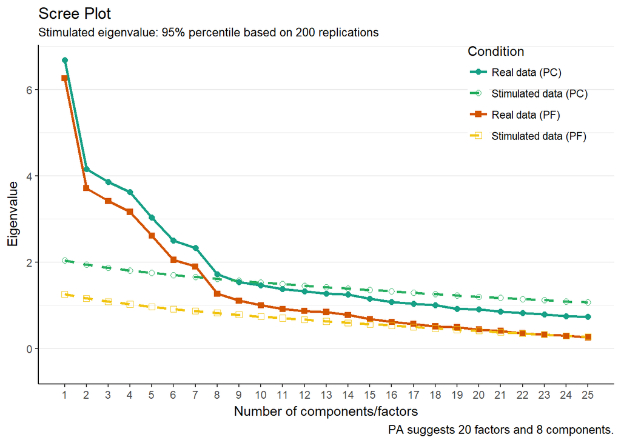

```
##
## For Female:
## Parallel analysis (PC) suggests 8 factor(s).
## Parallel analysis (PF) suggests 20 factor(s).
## MAP (1976) suggests 7 factor(s).
## MAP (2000) suggests 8 factor(s).
## EV > 1 rule suggests 18 factor(s).
##
## Number of factors
## Call: vss(x = x, n = n, rotate = rotate, diagonal = diagonal, fm = fm,
##     n.obs = n.obs, plot = FALSE, title = title, use = use, cor = cor)
## VSS complexity 1 achieves a maximimum of 0.43  with  7  factors
## VSS complexity 2 achieves a maximimum of 0.56  with  7  factors
## The Velicer MAP achieves a minimum of 0.01  with  7  factors
## Empirical BIC achieves a minimum of  -5412.21  with  8  factors
## Sample Size adjusted BIC achieves a minimum of  -653.83  with  11  factors
##
## Statistics by number of factors
##    vss1 vss2    map  dof chisq     prob sqresid  fit RMSEA   BIC SABIC
## 1  0.31 0.00 0.0175 1710  5892  0.0e+00      97 0.31 0.099 -3755  1667
## 2  0.32 0.42 0.0161 1651  5280  0.0e+00      82 0.42 0.094 -4034  1201
## 3  0.34 0.48 0.0147 1593  4700 2.9e-303      68 0.52 0.089 -4288   764
## 4  0.36 0.52 0.0128 1536  4119 1.1e-234      56 0.60 0.083 -4547   324
## 5  0.40 0.54 0.0110 1480  3599 2.7e-177      47 0.67 0.077 -4751   -58
## 6  0.41 0.56 0.0102 1425  3231 1.5e-141      43 0.70 0.073 -4808  -290
## 7  0.43 0.56 0.0097 1371  2908 1.6e-112      40 0.72 0.069 -4827  -479
## 8  0.42 0.55 0.0098 1318  2713  7.0e-99      38 0.73 0.067 -4723  -544
## 9  0.42 0.55 0.0101 1266  2523  6.1e-86      37 0.74 0.065 -4619  -605
## 10 0.40 0.54 0.0103 1215  2367  1.1e-76      36 0.74 0.064 -4488  -635
## 11 0.39 0.52 0.0106 1165  2225  6.1e-69      36 0.75 0.063 -4348  -654
##    complex eChisq  SRMR eCRMS  eBIC
## 1      1.0  13586 0.117 0.119  3938
## 2      1.4  10512 0.103 0.106  1197
## 3      1.6   7901 0.089 0.094 -1087
## 4      1.9   5607 0.075 0.080 -3059
## 5      1.9   4049 0.064 0.070 -4301
## 6      1.9   3122 0.056 0.062 -4918
## 7      1.9   2351 0.049 0.055 -5384
## 8      2.1   2024 0.045 0.052 -5412
## 9      2.3   1770 0.042 0.050 -5373
## 10     2.4   1562 0.040 0.048 -5293
## 11     2.6   1384 0.037 0.046 -5189
```

```r
for (i in 1:2){
 print(psych.pa(PA_polyglist[[i]], rep, baseline, 25))

 cat(paste0("\nFor ", dummy[i], ":\n",
           "Parallel analysis (PC) suggests ", as.character(PA_polyglist[[i]]$ncomp), " factor(s).\n",
           "Parallel analysis (PF) suggests ", as.character(PA_polyglist[[i]]$nfact), " factor(s).\n",
           "MAP (1976) suggests ", as.character(MAP_ployglist[[i]]$nfMAP), " factor(s).\n",
           "MAP (2000) suggests ", as.character(MAP_ployglist[[i]]$nfMAP4), " factor(s).\n",
           "EV > 1 rule suggests ", as.character(EVg[[i]]), " factor(s).\n"
          )
    )

 print(fit_ob[[i]])
}
```

```r
#rownames(item_info) = colnames(re_rawdf) # Must include the reverse item information to ensure there is no NA in dimension information
olsfa_Va_M = list()
for (i in factorrange){
olsfa_Va_M[[i]] = fa(item_poly_glist[[1]]$rho, n.obs = nrow(re_rawdf_glist[[1]]), nfactors = i,
                     rotate="varimax", residuals=T, SMC=T, max.iter = 50,
                     fm="minres", cor="poly")

}
ols_varimax_M = loadbar(olsfa_Va_M, item_info[,-4], type="Pattern", axis="maindim", extraction = "OLS", filename="faplot_varimax_male_NEW.pdf")
```

- 1~9個因素解 (OLS + Oblimin)的圖請查閱雲端的.pdf檔，或自行擷取程式碼執行。

```r
#rownames(item_info) = colnames(re_rawdf) # Must include the reverse item information to ensure there is no NA in dimension information
olsfa_Ob_M = list()
for (i in 1:9){
olsfa_Ob_M[[i]] = fa(item_poly_glist[[1]]$rho, n.obs = nrow(re_rawdf_glist[[1]]), nfactors = i,
                     rotate="oblimin", residuals=T, SMC=T, max.iter = 50,
                     fm="minres", cor="poly")

}
ols_oblimin_M = loadbar(olsfa_Ob_M, item_info[,-4], type="Pattern", axis="maindim", extraction = "OLS", filename="faplot_oblimin_P_male_NEW.pdf")
```

3. 樣式矩陣 (Female)
- 1~11個因素解 (OLS + Varimax)的圖請查閱雲端的.pdf檔，或自行擷取程式碼執行。

```r
#rownames(item_info) = colnames(re_rawdf) # Must include the reverse item information to ensure there is no NA in dimension information
olsfa_Va_F = list()
for (i in factorrange){
olsfa_Va_F[[i]] = fa(item_poly_glist[[2]]$rho, n.obs = nrow(re_rawdf_glist[[2]]), nfactors = i,
                     rotate="varimax", residuals=T, SMC=T, max.iter = 50,
                     fm="minres", cor="poly")
}

ols_varimax_F = loadbar(olsfa_Va_F, item_info[,-4], type="Pattern", axis="maindim", extraction = "OLS", filename="faplot_varimax_female_NEW.pdf")
```

- 1~11個因素解 (OLS + Oblimin)的圖請查閱雲端的.pdf檔，或自行擷取程式碼執行。

```r
#rownames(item_info) = colnames(re_rawdf) # Must include the reverse item information to ensure there is no NA in dimension information
olsfa_Ob_F = list()
for (i in factorrange){
olsfa_Ob_F[[i]] = fa(item_poly_glist[[2]]$rho, n.obs = nrow(re_rawdf_glist[[2]]), nfactors = i,
                     rotate="oblimin", residuals=T, SMC=T, max.iter = 50,
                     fm="minres", cor="poly")

}
ols_oblimin_F = loadbar(olsfa_Ob_F, item_info[,-4], type="Pattern", axis="maindim", extraction = "OLS", filename="faplot_oblimin_P_female.pdf")
```

4. Congruence coefficient
- A value of .90 or higher indicates similarity between corresponding factors (e.g., Reynolds & Harding, 1983; Reynolds, Lowe, & Saenz, 1999)
- `factor.congruence(A, B)`所產生的結果中，column是B因素解，row是A因素解。

```r
con_gender = factor.congruence(olsfa_Ob_F[[7]]$loadings, olsfa_Ob_M[[7]]$loadings, digits = 4)
con_all_F = factor.congruence(olsfa[[7]]$loadings, olsfa_Ob_F[[7]]$loadings, digits = 4)
con_all_M = factor.congruence(olsfa[[7]]$loadings, olsfa_Ob_M[[7]]$loadings, digits = 4)
print(con_gender); print(con_all_F); print(con_all_M)
```

```
##         MR3     MR2     MR1     MR6     MR4     MR5     MR7
## MR1  0.2210  0.8542  0.1780  0.1784 -0.0334 -0.0971 -0.0018
## MR3 -0.0085 -0.0006  0.8799  0.0990 -0.1293 -0.1169  0.1965
## MR2  0.0159 -0.0551 -0.0185 -0.0589  0.8531 -0.1203 -0.0775
## MR4  0.8355 -0.1380 -0.0290  0.0804 -0.0762  0.0626  0.1229
## MR6  0.2548  0.1349  0.0942  0.0022  0.0658  0.0931  0.8000
## MR7  0.1576 -0.0655  0.1322  0.8873 -0.0790 -0.0201  0.0890
## MR5 -0.0158  0.2530  0.0959 -0.0850  0.3067  0.8835  0.0492
```

```
##         MR1     MR3     MR2     MR4    MR6     MR7     MR5
## MR2  0.9536  0.0304 -0.1024 -0.0867 0.1208 -0.0031  0.1817
## MR1  0.1194  0.9719  0.0091  0.0108 0.0972  0.0920 -0.0012
## MR3  0.1516 -0.0054 -0.0090  0.9520 0.1704  0.1252 -0.0061
## MR4 -0.0134 -0.0462  0.9734 -0.0712 0.0113 -0.0233  0.1226
## MR7  0.1119  0.1115 -0.0248  0.0874 0.0679  0.9817 -0.0557
## MR5 -0.1486 -0.0879  0.0300  0.0238 0.1082 -0.0412  0.9686
## MR6 -0.0109  0.0942 -0.0179  0.0697 0.9579  0.0558  0.0649
```

```
##         MR3     MR2     MR1     MR6     MR4     MR5     MR7
## MR2  0.1096  0.9619  0.1520  0.0907  0.0067  0.0788  0.0347
## MR1 -0.0175  0.0286  0.9619  0.0732 -0.0844 -0.0847  0.1871
## MR3  0.9560 -0.0497 -0.0319  0.0844 -0.0351  0.0196  0.1103
## MR4  0.0034  0.0416 -0.0599 -0.0826  0.8996 -0.1221 -0.0928
## MR7  0.1140 -0.0399  0.1072  0.9397 -0.0994 -0.0112  0.0941
## MR5 -0.0504  0.1220  0.0568 -0.0660  0.2649  0.9537  0.0678
## MR6  0.1739  0.0954  0.0473 -0.0370  0.0094  0.0640  0.9120
```

```r
#write.csv(con_gender, "con_gender.csv"); write.csv(con_all_F, "con_all_F.csv"); write.csv(con_all_M, "con_all_M.csv")
```

# 10 Factorical Structure after Deleting Some Items

- Rule: Delete items with high item complexity (> 3) in 6-factor solution
1. Visualize item complexity

```r
#sort(olsfa[[6]]$complexity, decreasing = T)

##### Plot item complexity as scree plot

plotcom = function(falist){
  comlist = list()
  for (i in 2:length(falist)){

     if (!require("pacman")) install.packages("pacman"); library(pacman)
     p_load(ggplot2, dplyr)

     comdf = data.frame(item = names(falist[[i]]$complexity),
                        complexity = falist[[i]]$complexity) %>%
       arrange(desc(complexity))

     comdf$item = factor(comdf$item, levels = comdf$item)

     compcaption = paste0("Mean item complexity = ",
                         as.character(round(mean(falist[[i]]$complexity), 2)),
                         " (SD = ", as.character(round(sd(falist[[i]]$complexity), 2)), ")")


     comlist[[i]] = ggplot(comdf, aes(x=item, y=complexity)) +
        geom_bar(aes(y=complexity), stat = 'identity', colour = "white", fill = "#CCCCFF") +
        labs(x="Item",y = "Item complexity", title = "Plot of Item Complexity",
             subtitle = paste0(as.character(i), " factors solution"), caption = compcaption) +
      geom_hline(aes(yintercept = mean(complexity)), color="#e74c3c", size = 1.5, alpha = 0.5) +
      theme_bw() +
      theme(axis.line = element_line(colour = "black"), # Make "l" type axis
        panel.border = element_blank(), # Make "L" type axis
        legend.background = element_rect(fill = "transparent", size = .5, linetype = "dotted"),
        axis.ticks.x=element_blank(),
        panel.grid.major.x = element_blank(), # Suppress major vertical gridlines
        panel.grid.minor.x = element_blank(), # Suppress minor vertical gridlines
        panel.background = element_rect(fill = "transparent", colour = NA), # Background transparent
        plot.background = element_rect(fill = "transparent", colour = NA)) # Background transparent
  }
  return(comlist)
}
olsfa_com = plotcom(olsfa)
```

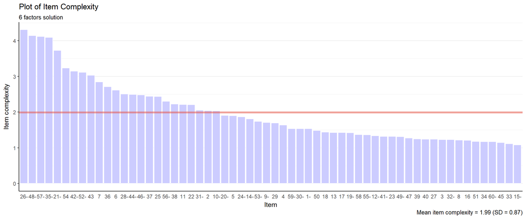

```r
olsfa_com[[6]]
```

```r
# Delete specific item cols (complexity >= 3) by `select`
# https://stackoverflow.com/questions/25923392/select-columns-based-on-string-match-dplyrselect
highitemcom = names(subset(olsfa[[6]]$complexity, olsfa[[6]]$complexity >= 3))
re_rawdf_del = select(as.data.frame(re_rawdf), -one_of(highitemcom))
item_poly_del = polychoric(re_rawdf_del, ML = F, std.err = F)
```

```
## 686 cells were adjusted for 0 values using the correction for continuity. Examine your data carefully.
```

```r
n_var_del = ncol(re_rawdf_del)

rownames(item_info) = colnames(re_rawdf)
item_info_del = subset(item_info, !(rownames(item_info) %in% highitemcom))
```

1. Overall
- 9因素解之後都未達收斂。

```r
olsfa_del = list()
subject = nrow(re_rawdf_del)
for (i in 1:8){
olsfa_del[[i]] = fa(item_poly_del$rho, n.obs = subject, nfactors = i,
                    rotate="oblimin", residuals=T, SMC=T, max.iter = 50,
                    fm="minres", cor="poly")
}
faplot.list = list()
loadbar(olsfa_del, item_info_del[,-4], type="Pattern", axis="maindim", extraction = "OLS", filename="faplot_oblique_P_del.pdf")
```

2. By gender
- Male: Not converged until 12 factors.
- Feale: Not converged until 13 factors.

```r
re_rawdf_glist_del = list(); item_poly_glist_del = list()
for (i in 1:2){
  re_rawdf_glist_del[[i]] = select(as.data.frame(re_rawdf_glist[[i]]), -one_of(highitemcom))
  item_poly_glist_del[[i]] = polychoric(re_rawdf_glist_del[[i]], ML = F, std.err = F)
}
```

```
## 1118 cells were adjusted for 0 values using the correction for continuity. Examine your data carefully.
```

```
## 1135 cells were adjusted for 0 values using the correction for continuity. Examine your data carefully.
```

```r
olsfa_Ob_M_del = list()
for (i in 1:11){
olsfa_Ob_M_del[[i]] = fa(item_poly_glist_del[[1]]$rho, n.obs = nrow(re_rawdf_glist_del[[1]]), nfactors = i,
                         rotate="oblimin", residuals=T, SMC=T, max.iter = 50, fm="minres", cor="poly")
}

ols_oblimin_M_del = loadbar(olsfa_Ob_M_del, item_info_del[,-4], type="Pattern", axis="maindim", extraction = "OLS", filename="faplot_oblimin_male_del.pdf")

olsfa_Ob_F_del = list()
for (i in 1:12){
olsfa_Ob_F_del[[i]] = fa(item_poly_glist_del[[2]]$rho, n.obs = nrow(re_rawdf_glist_del[[2]]), nfactors = i,
                         rotate="oblimin", residuals=T, SMC=T, max.iter = 50, fm="minres", cor="poly")
}

ols_oblimin_F_del = loadbar(olsfa_Ob_F_del, item_info_del[,-4], type="Pattern", axis="maindim", extraction = "OLS", filename="faplot_oblimin_female_del.pdf")
```

# 11 FA of Facets

## 11.1 計分、KMO與因素數目 (Pearson cor)

```r
### 各facet計分
facet.keys.list = list(Sincerity = c(6, -30, 54), Fairness = c(-12, 36, -60),
                       Greed_Avoidance = c(18, -42), Modesty = c(-24, -48),
                       Fearfulness = c(5, 29, -53), Anxiety = c(11, -35),
                       Dependence = c(17, -41), Sentimentality = c(23, 47, -59),
                       Social_Self_Esteem = c(4, -28, -52), Social_Boldness = c(-10, 34, 58),
                       Sociability = c(16, 40), Liveliness = c(22, -46),
                       Forgiveness = c(3, 27), Gentleness = c(-9, 33, 51),
                       Flexibility = c(-15, 39, -57), Patience = c(-21, 45),
                       Organization = c(2, -26), Diligence = c(8, -32),
                       Perfectionism = c(-14, 38, 50), Prudence = c(-20, -44, -56),
                       Aesthetic_Appreciation = c(-1, 25), Inquisitiveness = c(7, -31),
                       Creativity = c(13, 37, -49), Unconventionality = c(-19, 43, -55))
facet.keys = make.keys(itemonly, facet.keys.list)

facet.scored = scoreItems(keys = facet.keys, items = itemonly, totals = FALSE,
                          missing = FALSE, min = 1, max = 5, digits = 3)
facetscore = cbind(as.data.frame(facet.scored$scores), rawdf[, 2:10])
colnames(facetscore)[c(3, 9, 10, 21)] = c("Greed Avoidance", "Social Self-Esteem", "Social Boldness", "Aesthetic Appreciation")

### KMO & Bartlett test

facet_cor = cor(facetscore[,1:24])
facet_KMO = KMO(facet_cor)
print(facet_KMO)
```

```
## Kaiser-Meyer-Olkin factor adequacy
## Call: KMO(r = facet_cor)
## Overall MSA =  0.74
## MSA for each item =
##              Sincerity               Fairness        Greed Avoidance
##                   0.69                   0.79                   0.75
##                Modesty            Fearfulness                Anxiety
##                   0.70                   0.77                   0.76
##             Dependence         Sentimentality     Social Self-Esteem
##                   0.67                   0.65                   0.80
##        Social Boldness            Sociability             Liveliness
##                   0.67                   0.66                   0.78
##            Forgiveness             Gentleness            Flexibility
##                   0.76                   0.74                   0.79
##               Patience           Organization              Diligence
##                   0.78                   0.79                   0.76
##          Perfectionism               Prudence Aesthetic Appreciation
##                   0.69                   0.68                   0.75
##        Inquisitiveness             Creativity      Unconventionality
##                   0.76                   0.67                   0.77
```

```r
subject = nrow(re_rawdf)
cortest.bartlett(facet_cor, n = subject)
```

```
## $chisq
## [1] 2669.748
##
## $p.value
## [1] 0
##
## $df
## [1] 276
```

```r
### Factor Number
PA_facet = fa.parallel(facet_cor, n.obs = subject, fa = "both", n.iter = rep,
                       cor = "cor", error.bars = F, SMC = T, quant = baseline/100)
```

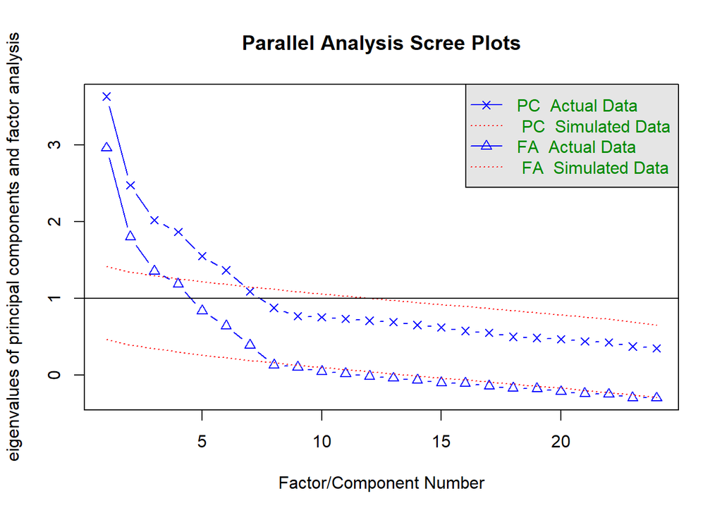

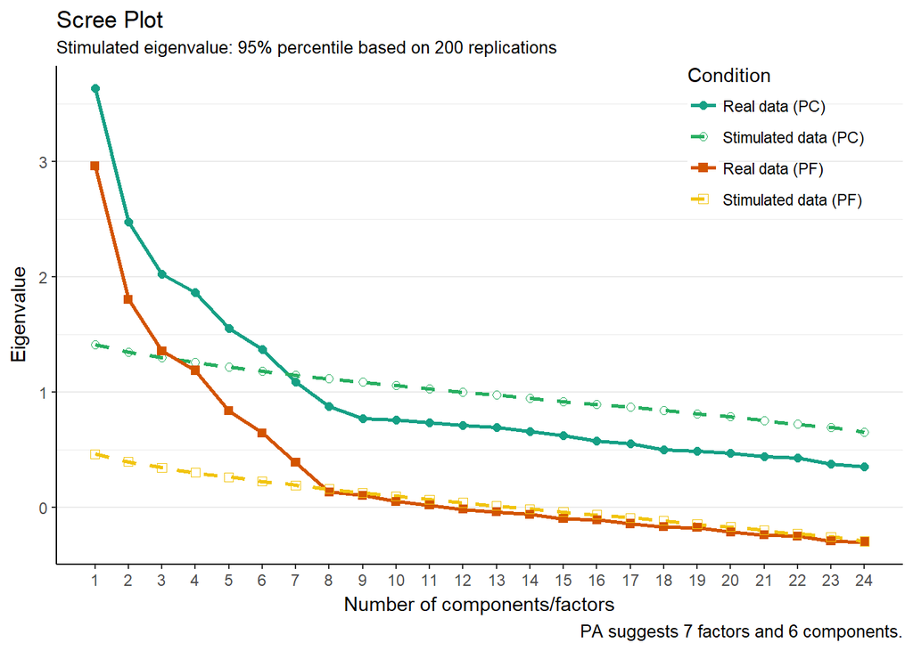

```r
psych.pa(PA_facet, rep, baseline, 24)
```

```r
MAP_facet = map(facet_cor, display='yes')
```

```
##
## Velicer's Minimum Average Partial Test
##
##
##  The entered data is a correlation matrix.
##
##
## Eigenvalues:
##
##  root  eigenvalue
##     1     3.63267
##     2     2.47674
##     3     2.02265
##     4     1.86544
##     5     1.55404
##     6     1.36683
##     7     1.08930
##     8     0.87656
##     9     0.76912
##    10     0.75662
##    11     0.73468
##    12     0.70894
##    13     0.69113
##    14     0.65521
##    15     0.62295
##    16     0.57787
##    17     0.55134
##    18     0.49922
##    19     0.48575
##    20     0.46960
##    21     0.44143
##    22     0.42731
##    23     0.37421
##    24     0.35038
##
##
## Velicer's Average Squared Correlations
##
##  root   Avg.Corr.Sq.   Avg.Corr.power4
##     0        0.02649           0.00242
```

[output cut: 17 more lines]

```
##    18        0.14663           0.04987
##    19        0.18367           0.07601
##    20        0.22663           0.10474
##    21        0.31320           0.18275
##    22        0.48999           0.36080
##    23        1.00000           1.00000
##
##
## The smallest average squared correlation is       0.01738
##
## The smallest average 4rth power correlation is    0.00075
##
## The Number of Factors According to the Original (1976) MAP Test is =   4
##
## The Number of Factors According to the Revised  (2000) MAP Test is =   4
```

```r
fit_facet = nfactors(facet_cor, n = 10, rotate = "oblimin", diagonal=F, fm = "minres",
                     n.obs=subject, cor = "cor")
```

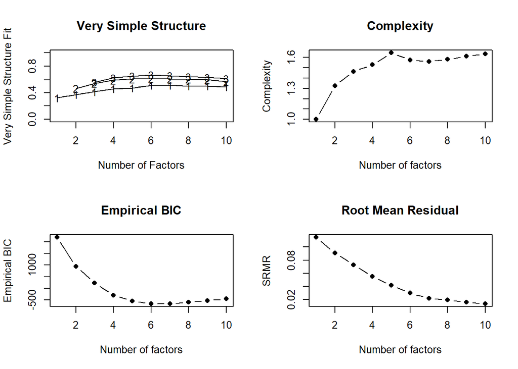

```r
print(fit_facet)
```

```
##
## Number of factors
## Call: vss(x = x, n = n, rotate = rotate, diagonal = diagonal, fm = fm,
##     n.obs = n.obs, plot = FALSE, title = title, use = use, cor = cor)
## VSS complexity 1 achieves a maximimum of 0.51  with  7  factors
## VSS complexity 2 achieves a maximimum of 0.61  with  6  factors
## The Velicer MAP achieves a minimum of 0.02  with  4  factors
## Empirical BIC achieves a minimum of  -666.17  with  7  factors
## Sample Size adjusted BIC achieves a minimum of  -187.07  with  8  factors
##
## Statistics by number of factors
##    vss1 vss2   map dof chisq     prob sqresid  fit RMSEA  BIC SABIC
## 1  0.32 0.00 0.020 252  1860 1.0e-242      26 0.32 0.112  284  1084
## 2  0.37 0.46 0.019 229  1397 1.5e-166      21 0.46 0.100  -35   692
## 3  0.41 0.54 0.018 207  1015 9.2e-107      17 0.56 0.088 -279   378
## 4  0.46 0.59 0.017 186   691  3.8e-59      14 0.63 0.073 -472   118
## 5  0.47 0.61 0.018 166   465  4.4e-30      13 0.67 0.060 -573   -46
## 6  0.51 0.61 0.019 147   314  3.9e-14      12 0.69 0.048 -605  -139
## 7  0.51 0.61 0.021 129   210  8.6e-06      11 0.70 0.036 -597  -187
## 8  0.50 0.60 0.025 112   158  2.9e-03      12 0.69 0.029 -543  -187
## 9  0.50 0.59 0.030  96   118  6.4e-02      12 0.69 0.023 -482  -178
## 10 0.49 0.57 0.035  81    86  3.4e-01      12 0.68 0.013 -421  -164
##    complex eChisq  SRMR eCRMS eBIC
## 1      1.0   3775 0.115 0.120 2200
## 2      1.3   2374 0.091 0.100  943
## 3      1.5   1527 0.073 0.084  232
## 4      1.5    866 0.055 0.067 -297
## 5      1.6    495 0.042 0.054 -543
## 6      1.6    254 0.030 0.041 -665
## 7      1.6    140 0.022 0.032 -666
## 8      1.6    106 0.019 0.030 -594
## 9      1.6     75 0.016 0.027 -526
## 10     1.6     53 0.014 0.025 -453
```

```r
sum(eigen(facet_cor, only.values = T)$values > 1)
```

```
## [1] 7
```

## 11.2 Estimation of Factor Loadings (OLS + Oblimin: 1-10 factors)

- A loading greater than abs(1) was detected when nfactor = 11.

```r
olsfa_facet = list()
for (i in 1:10){
olsfa_facet[[i]] = fa(facet_cor, n.obs = subject, nfactors = i,
                      rotate = "oblimin", residuals=T, SMC=T, max.iter = 50,
                      fm = "minres", cor = "cor")
}

### Make a data.frame called "facetinfo" for `loadbar` function

facet.item = vector()
for (i in 1:length(facet.keys.list)){
  facet.item = append(facet.item, paste(facet.keys.list[[i]], collapse = " "))
}


facet_info = data.frame(maindim = rep(c("H", "E", "X", "A", "C", "O"), each = 4),
                        item = facet.item)
row.names(facet_info) = colnames(facetscore)[1:24]
```

- 新建一個函數來繪製子向度與大向度的關係：`loadbar.facet` * HEXACO理論架構在六因素解可被重製。

```r
loadbar.facet = function(loading, facetinfo, type="Pattern", axis="maindim", extraction = "Unknown", filename="faplots_facet.pdf", rel_widths = c(4,1), widthpdf = 15, widthheight = 11){

  # Create the empty list first to save ggplot objects
  faplot.list = list()

  ################ Check packages by `pacman` ################

  if (!require("pacman")) install.packages("pacman"); library(pacman)
  p_load(reshape2, ggplot2, cowplot, grid, dplyr, psych)

  loadmat = list()

  if (type == "Pattern"){
    hlab = "Loading Strength"
    for(i in 1:length(loading)){
      loadmat[[i]] = fa.lookup(loading[[i]], facetinfo, digits = 4)
    }
  }
  else if (type == "Structure"){
    hlab = "Correlation (Factors, Varibles)"
    for(i in 1:length(loading)){
      item_cc = data.frame(rownames= row.names(loading[[i]]$Structure),
                           h2 = loading[[i]]$communality, com = loading[[i]]$complexity)
      loadmat[[i]] = fa.lookup(loading[[i]]$Structure, facetinfo, digits = 4)
      loadmat[[i]] = inner_join(cbind(loadmat[[i]], rownames = row.names(loadmat[[i]])), item_cc, by = "rownames")
      row.names(loadmat[[i]]) = loadmat[[i]]$rownames
      loadmat[[i]] = select(loadmat[[i]], -rownames)

    }
  }

  loadmat_l = list()

  for (i in 1:length(loadmat)){

    ################ Data transformation for further plotting ################
    loadmat[[i]] = cbind(loadmat[[i]], facet = row.names(loadmat[[i]]))

    complexity = paste0("Mean facet complexity = ", as.character(round(mean(loadmat[[i]]$com), 2)),
                        " (SD = ", as.character(round(sd(loadmat[[i]]$com), 2)), ")")
    submain = paste0(extraction, " method with ", loading[[i]]$rotation, " rotation. (N = ", loading[[i]]$n.obs,")")
    fit = paste0("RMSEA = ", as.character(round(loading[[i]]$RMSEA[1],3)),
                 "; BIC = ", as.character(round(loading[[i]]$BIC,3)),
                 "; TLI = ", as.character(round(loading[[i]]$TLI,3)),".")

    loadmat_l[[i]] = melt(loadmat[[i]], id = c("com","h2","maindim","item","facet"),
                          measure = subset(colnames(loadmat[[i]]),
                                           colnames(loadmat[[i]])!="com"&
                                           colnames(loadmat[[i]])!="h2"&
                                           colnames(loadmat[[i]])!="maindim"&
                                           colnames(loadmat[[i]])!="item"&
                                           colnames(loadmat[[i]])!="facet"),
                          variable.name="Factor", value.name="Loading")

    # To make x-axis of ggplot follow the specific order (original pattern/structure matrix order)
    loadmat_l[[i]]$facet = factor(loadmat_l[[i]]$facet, levels = loadmat[[i]]$facet)

    if (axis == "item"){
      align = 0
      vlab = "Facet & Item"
      vlabel = loadmat_l[[i]]$item
    }
    else if (axis == "maindim"){
      align = 1
      vlab = "Facet & Dimension"
      vlabel = loadmat_l[[i]]$maindim
    }

    loadmat_l[[i]]$Communality = factor(rep("Communality", nrow(loadmat_l[[i]])))

    ################ Plot Pattern/Structure Matrix ################

    assign("PS", ggplot(loadmat_l[[i]], aes(facet, abs(Loading), fill = Loading)) +
      facet_wrap(~ Factor, nrow = 1) +
      geom_bar(stat = "identity") +
      coord_flip() +
      # Define the fill color gradient: blue=positive, red=negative
      scale_fill_gradient2(name = "Loading",
                           high = "blue", mid = "white", low = "red",
                           midpoint = 0, guide = F) +
      #scale_x_discrete(labels = vlabel) + ################################3
      labs(x = vlab, y = hlab, title = paste("Barplot of the", type,"Matrix"), subtitle = submain, caption = "") +
      theme_bw(base_size = 10) + #use a black-and white theme with set font size
      theme(axis.text.y=element_text(hjust=align), # Align of the `axis`
            #legend.position=c(.85, .85),
            #legend.background = element_rect(fill="transparent", size=.5, linetype="dotted"),
            #text=element_text(family="華康中黑體", size=10),
            strip.background = element_rect(colour="transparent", fill="#CCCCFF"), # facet label color
            panel.background = element_rect(fill = "transparent", colour = NA),
            panel.border = element_blank(), #element_rect(colour = "#CCCCFF"),
            plot.background = element_rect(fill = "transparent", colour = NA)) +
      background_grid(major = 'x', minor = "none"))# +
      #panel_border(colour = "#CCCCFF"): The same with panel.background in theme

    ################ Plot Communality ################

    assign("COM", ggplot(distinct(loadmat_l[[i]], facet, h2, Communality), aes(facet, h2, fill = h2)) +
      geom_bar(stat = "identity") +
      facet_wrap(~ Communality, nrow = 1) +
      coord_flip() +
      scale_fill_gradient2(name = "h2",
                           high = "black", mid = "grey", low = "white",
                           midpoint = 0, guide = F) +
      scale_x_discrete(labels = vlabel) +
      labs(y = "Communality", title="", subtitle = complexity, caption = fit) +
      theme_bw(base_size = 10) +
      theme(axis.text.y=element_text(hjust=0), # Retain y axis labels for convenience
            axis.line.y = element_line(colour = "black"), # Make "l" type axis
            panel.border = element_blank(), # Suppress border
            strip.background = element_rect(colour="transparent", fill="gray80"), # facet label color
            axis.title.y=element_blank(), # Remove y axis lab for beauty
            axis.ticks.y=element_blank(), # Remove y axis ticks for beauty
            panel.background = element_rect(fill = "transparent", colour = NA),
            plot.background = element_rect(fill = "transparent", colour = NA)) +
      background_grid(major = 'x', minor = "none"))

    ################ Marge two plot  ################

    g.PS = ggplotGrob(PS); g.COM = ggplotGrob(COM)
    PS.heights = g.PS$heights[1:3]
    COM.heights = g.COM$heights[1:3] # same for mpg plot
    max.heights = unit.pmax(PS.heights, COM.heights) # calculate maximum heights
    g.PS$heights[1:3] = max.heights # assign max heights to PS gtable
    g.COM$heights[1:3] = max.heights # assign max heights to COM gtable

    # plot_grid() can work directly with gtables, so this works!
    faplot.list[[i]] = plot_grid(g.PS, g.COM, ncol = 2, rel_widths = rel_widths)

  }

  ################ Create pdf where each page is a separate plot ################

  pdf(filename, width = widthpdf, height = widthheight)
  for (i in 1:length(loadmat)) {
    print(faplot.list[[i]])
  }
  dev.off()

  cat("The ggplot objects are saved into a list you assign.\n\nFor example, if you assign the `loadpar` function into a variable called `faplot`, i.e., `faplot = loadpar(...)`, then the plot of m factor solution can be called by `faplot[[m]]`.\n\nFor converience, all plots are saved into a single pdf file in the working directory.")

  return(faplot.list) # Return the ggplot object for further use

}

ols_oblimin_facet = loadbar.facet(olsfa_facet, facet_info, type="Pattern", axis="maindim", extraction = "OLS", filename="faplot_oblique_P_facet_dim.pdf")
```

```
## The ggplot objects are saved into a list you assign.
##
## For example, if you assign the `loadpar` function into a variable called `faplot`, i.e., `faplot = loadpar(...)`, then the plot of m factor solution can be called by `faplot[[m]]`.
##
## For converience, all plots are saved into a single pdf file in the working directory.
```

```r
#olsfa_facet_6 = fa.lookup(olsfa_facet[[6]], facet_info, digits = 4)
#write.csv(olsfa_facet_6, "ols6_oblique_P_facet.csv") # 匯出成.csv時有些item會有亂碼
#write.csv(olsfa_facet[[6]]$Phi, "ols6_oblique_Phi_facet.csv")
```